# seurat_pattern (SAVER)

Taewan Kim

5/30/2022

# 1. Import Data and Library

```r
library(Seurat)
library(SeuratData)
```

```r
library(cowplot)
library(dplyr)
load("CD4_dat.rds")
load("CD4_cor_mat.rds")

cor_pearson_mat <- cor_mat_list[[1]]; cor_spearman_mat <- cor_mat_list[[2]];
cor_kendall_mat <- cor_mat_list[[3]]; cor_hoeffd_mat <- cor_mat_list[[4]];
cor_blomqvist_mat <- cor_mat_list[[5]]; cor_MI_mat <- cor_mat_list[[6]];
cor_dist_mat <- cor_mat_list[[7]]; cor_XI_mat <- cor_mat_list[[8]];
```

```r
load("CD4_seurat_corrq.RData")

quantile_mat
```

```
##                           15%        85%
## Pearson          0.0063573876 0.20926968
## Spearman         0.0175490367 0.33646081
## Kendall          0.0143049742 0.25347375
## Hoeffding's D              NA         NA
## Blomqvist's Beta 0.9893333333 1.00000000
## Dist. Corr       0.0173682245 0.35759836
## NMI              0.0005631287 0.07361977
## XI Corr          0.0031408643 0.08356398
```

# 2. Find contrast characteristics among the correlation coefficients above

```r
contrast_helper <- function(contrast_ind, threshold){
  to_track <- data.frame()

  if (nrow(contrast_ind) == 0){
    return (contrast_ind)
  }

  for (i in 1:nrow(contrast_ind)){
    ind1 <- contrast_ind[i, 1]; ind2 <- contrast_ind[i, 2];

    if (i == 1){ # first element
      to_track <- data.frame(row.names = c(ind1, ind2), val = c(1, 1))
      ans <- matrix(contrast_ind[i, ], nrow = 1)
    } else {
      if (nrow(ans) == 10) { # want to extract 10 pairs
        break
      } else {
        row_names <- row.names(to_track)
        ind1_str <- toString(ind1); ind2_str <- toString(ind2);

        if (ind1_str %in% row_names){
          first_bool <- to_track[ind1_str, ] < threshold
          to_track[ind1_str, ] <- to_track[ind1_str, ] + 1
        } else {
          to_track[ind1_str, ] <- 1
          first_bool <- TRUE
        }

        if (ind2_str %in% row_names){
          second_bool <- to_track[ind2_str, ] < threshold
          to_track[ind2_str, ] <- to_track[ind2_str, ] + 1
        } else {
          to_track[ind2_str, ] <- 1
          second_bool <- TRUE
        }

        if (first_bool & second_bool){
          ans <- rbind(ans, contrast_ind[i,])
        }
      }
    }
  }
  return (ans)
}
```

## 2-1-1. Low Pearson (< 10%) and High Spearman (> 95%) (linearity vs monotone)

```r
cor_contrast1 <- ((abs(cor_pearson_mat) < quantile_mat["Pearson", 1]) &
                  (abs(cor_spearman_mat) > quantile_mat["Spearman", 2]))
cor_contrast_ind1 <- which(cor_contrast1, arr.ind = T)
cor_contrast_ind1 <- contrast_helper(cor_contrast_ind1, 3)

nrow(cor_contrast_ind1)
```

```
## [1] 10
```

## 2-1-2. Visualization of Low Pearson (< 10%) and High Spearman (> 95%) (linearity vs monotone)

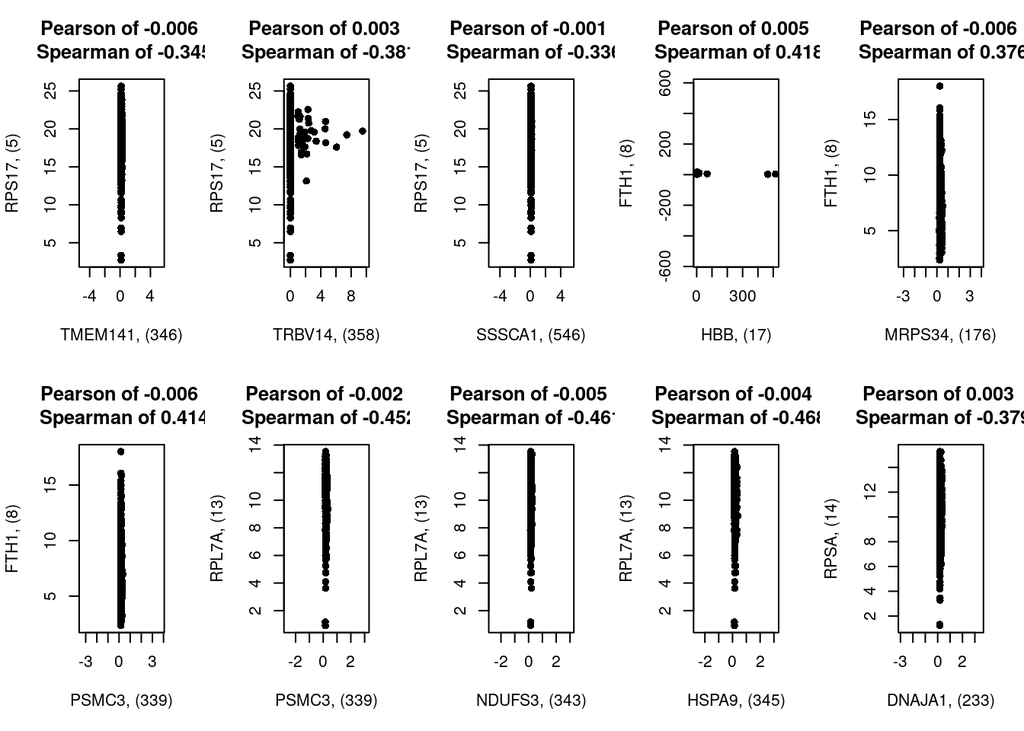

```r
par(mfrow = c(2, 5))
for (i in 1:nrow(cor_contrast_ind1)){
  index1 <- cor_contrast_ind1[i, 1]; index2 <- cor_contrast_ind1[i, 2]
  plot(sub_dat[,index1], sub_dat[,index2], asp = T,
       pch = 16, xlab = paste0(colnames(sub_dat)[index1], ", (", index1, ")"),
       ylab = paste0(colnames(sub_dat)[index2], ", (", index2, ")"),
       main = paste(paste0("Pearson of ", round(cor_pearson_mat[index1, index2], 3)),
                    "\n",
                    paste0("Spearman of ", round(cor_spearman_mat[index1, index2], 3))))
}
```

## 2-2-1. High Pearson (> 95%) and Low Spearman (< 10%) (linearity vs monotone)

```r
cor_contrast2 <- ((abs(cor_pearson_mat) > quantile_mat["Pearson", 2]) &
                  (abs(cor_spearman_mat) < quantile_mat["Spearman", 1]))
cor_contrast_ind2 <- which(cor_contrast2, arr.ind = T)
cor_contrast_ind2 <- contrast_helper(cor_contrast_ind2, 3)

nrow(cor_contrast_ind2)
```

```
## [1] 10
```

## 2-2-2. Visualization of High Pearson (> 95%) and Low Spearman (< 10%) (linearity vs monotone)

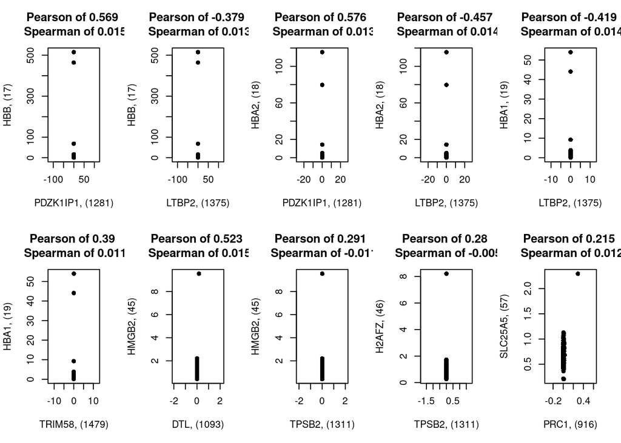

```r
par(mfrow = c(2, 5))
for (i in 1:nrow(cor_contrast_ind2)){
  index1 <- cor_contrast_ind2[i, 1]; index2 <- cor_contrast_ind2[i, 2]
  plot(sub_dat[,index1], sub_dat[,index2], asp = T,
       pch = 16, xlab = paste0(colnames(sub_dat)[index1], ", (", index1, ")"),
       ylab = paste0(colnames(sub_dat)[index2], ", (", index2, ")"),
       main = paste(paste0("Pearson of ", round(cor_pearson_mat[index1, index2], 3)),
                    "\n",
                    paste0("Spearman of ", round(cor_spearman_mat[index1, index2], 3))))
}
```

## 2-3-1. Low Pearson (< 10%) and High Kendall (> 95%) (linearity vs monotone)

```r
cor_contrast3 <- ((abs(cor_pearson_mat) < quantile_mat["Pearson", 1]) &
                  (abs(cor_kendall_mat) > quantile_mat["Kendall", 2]))
cor_contrast_ind3 <- which(cor_contrast3, arr.ind = T)
cor_contrast_ind3 <- contrast_helper(cor_contrast_ind3, 3)

nrow(cor_contrast_ind3)
```

```
## [1] 10
```

## 2-3-2. Visualization of Low Pearson (< 10%) and High Kendall (> 95%) (linearity vs monotone)

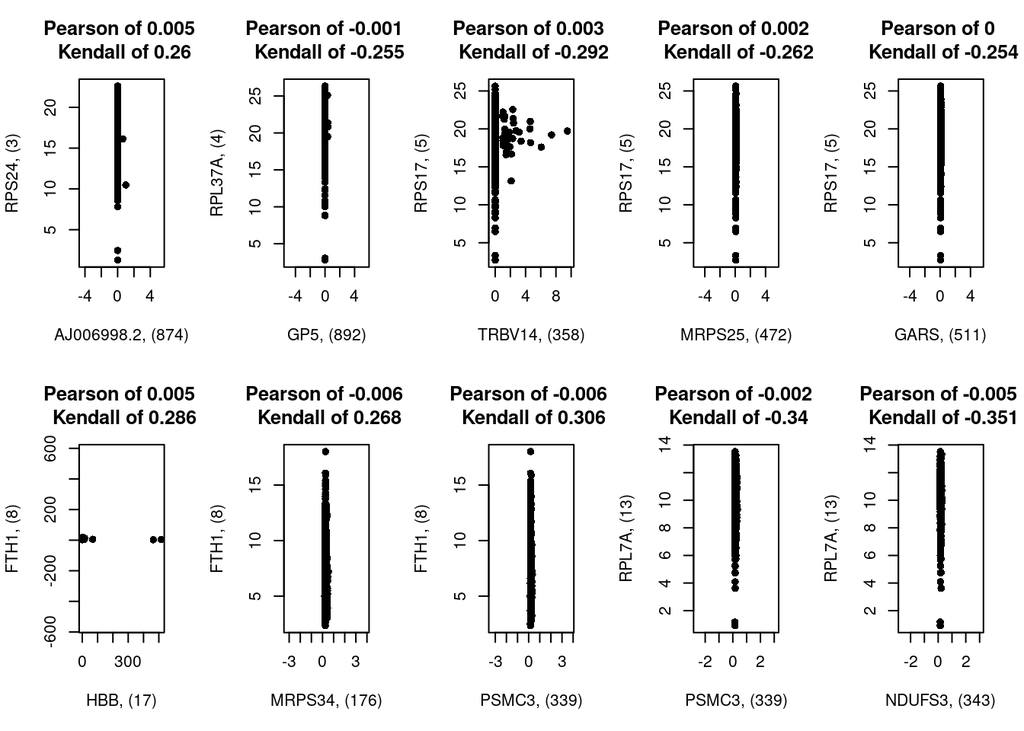

```r
par(mfrow = c(2, 5))
for (i in 1:nrow(cor_contrast_ind3)){
  index1 <- cor_contrast_ind3[i, 1]; index2 <- cor_contrast_ind3[i, 2]
  plot(sub_dat[,index1], sub_dat[,index2], asp = T,
       pch = 16, xlab = paste0(colnames(sub_dat)[index1], ", (", index1, ")"),
       ylab = paste0(colnames(sub_dat)[index2], ", (", index2, ")"),
       main = paste(paste0("Pearson of ", round(cor_pearson_mat[index1, index2], 3)),
                    "\n",
                    paste0("Kendall of ", round(cor_kendall_mat[index1, index2], 3))))
}
```

## 2-4-1. High Pearson (> 95%) and Low Kendall (< 10%) (linearity vs monotone)

```r
cor_contrast4 <- ((abs(cor_pearson_mat) > quantile_mat["Pearson", 2]) &
                  (abs(cor_kendall_mat) < quantile_mat["Kendall", 1]))
cor_contrast_ind4 <- which(cor_contrast4, arr.ind = T)
cor_contrast_ind4 <- contrast_helper(cor_contrast_ind4, 3)

nrow(cor_contrast_ind4)
```

```
## [1] 10
```

## 2-4-2. Visualization of High Pearson (> 95%) and Low Kendall (< 10%) (linearity vs monotone)

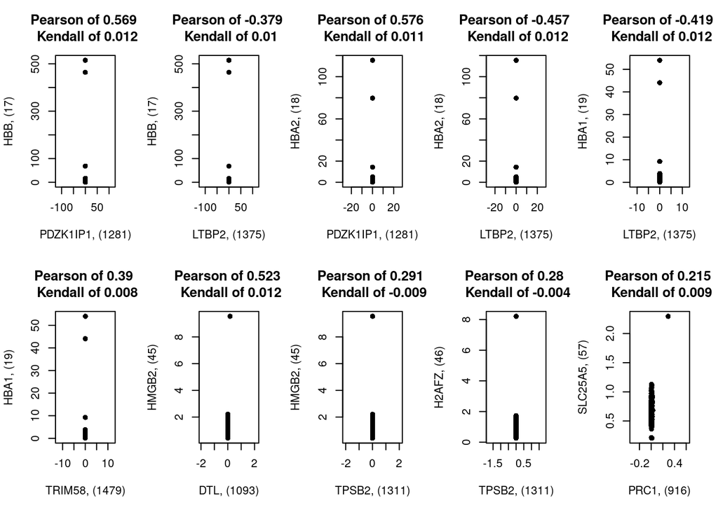

```r
par(mfrow = c(2, 5))
for (i in 1:nrow(cor_contrast_ind4)){
  index1 <- cor_contrast_ind4[i, 1]; index2 <- cor_contrast_ind4[i, 2]
  plot(sub_dat[,index1], sub_dat[,index2], asp = T,
       pch = 16, xlab = paste0(colnames(sub_dat)[index1], ", (", index1, ")"),
       ylab = paste0(colnames(sub_dat)[index2], ", (", index2, ")"),
       main = paste(paste0("Pearson of ", round(cor_pearson_mat[index1, index2], 3)),
                    "\n",
                    paste0("Kendall of ", round(cor_kendall_mat[index1, index2], 3))))
}
```

## 2-5-1. Low Pearson (< 10%) and High Hoeffding’s D (> 95%) (linearity vs monotone)

```r
# cor_contrast5 <- ((abs(cor_pearson_mat) < quantile_mat["Pearson", 1]) &
#                   (abs(cor_hoeffd_mat) > quantile_mat["Hoeffding's D", 2]))
# cor_contrast_ind5 <- which(cor_contrast5, arr.ind = T)
# cor_contrast_ind5 <- contrast_helper(cor_contrast_ind5, 3)
#
# nrow(cor_contrast_ind5)
```

## 2-5-2. Visualization of Low Pearson (< 10%) and High Hoeffding’s D (> 95%) (linearity vs monotone)

```r
# par(mfrow = c(2, 5))
# for (i in 1:nrow(cor_contrast_ind5)){
#   index1 <- cor_contrast_ind5[i, 1]; index2 <- cor_contrast_ind5[i, 2]
#   plot(sub_dat[,index1], sub_dat[,index2], asp = T,
#        pch = 16, xlab = paste0(colnames(sub_dat)[index1], ", (", index1, ")"),
#        ylab = paste0(colnames(sub_dat)[index2], ", (", index2, ")"),
#        main = paste(paste0("Pearson of ", round(cor_pearson_mat[index1, index2], 3)),
#                     "\n",
#                     paste0("Hoeff D of ", round(cor_hoeffd_mat[index1, index2], 3))))
# }
```

## 2-6-1. High Pearson (> 95%) and Low Hoeffding’s D (< 10%) (linearity vs monotone)

```r
# cor_contrast6 <- ((abs(cor_pearson_mat) > quantile_mat["Pearson", 2]) &
#                   (abs(cor_hoeffd_mat) < quantile_mat["Hoeffding's D", 1]))
# cor_contrast_ind6 <- which(cor_contrast6, arr.ind = T)
# cor_contrast_ind6 <- contrast_helper(cor_contrast_ind6, 3)
#
# nrow(cor_contrast_ind6)
```

## 2-6-2. Visualization of High Pearson (> 95%) and Low Hoeffding’s D (< 10%) (linearity vs monotone)

```r
# par(mfrow = c(2, 5))
# for (i in 1:nrow(cor_contrast_ind6)){
#   index1 <- cor_contrast_ind6[i, 1]; index2 <- cor_contrast_ind6[i, 2]
#   plot(sub_dat[,index1], sub_dat[,index2], asp = T,
#        pch = 16, xlab = paste0(colnames(sub_dat)[index1], ", (", index1, ")"),
#        ylab = paste0(colnames(sub_dat)[index2], ", (", index2, ")"),
#        main = paste(paste0("Pearson of ", round(cor_pearson_mat[index1, index2], 3)),
#                     "\n",
#                     paste0("Hoeff D of ", round(cor_hoeffd_mat[index1, index2], 3))))
# }
```

## 2-7-1. Low Pearson (< 10%) and high Blomqvist’s beta (> 95%) (linearity vs monotone)

```r
cor_contrast7 <- ((abs(cor_pearson_mat) < quantile_mat["Pearson", 1]) &
                  (abs(cor_blomqvist_mat) > quantile_mat["Blomqvist's Beta", 2]))
cor_contrast_ind7 <- which(cor_contrast7, arr.ind = T)
cor_contrast_ind7 <- contrast_helper(cor_contrast_ind7, 3)

nrow(cor_contrast_ind7)
```

```
## [1] 0
```

## 2-7-2. Visualization of Low Pearson (< 10%) and high Blomqvist’s beta (> 95%) (linearity vs monotone)

```r
# par(mfrow = c(2, 5))
# for (i in 1:nrow(cor_contrast_ind7)){
#   index1 <- cor_contrast_ind7[i, 1]; index2 <- cor_contrast_ind7[i, 2]
#   plot(sub_dat[,index1], sub_dat[,index2], asp = T,
#        pch = 16, xlab = paste0(colnames(sub_dat)[index1], ", (", index1, ")"),
#        ylab = paste0(colnames(sub_dat)[index2], ", (", index2, ")"),
#        main = paste(paste0("Pearson of ", round(cor_pearson_mat[index1, index2], 3)),
#                     "\n",
#                     paste0("Beta of ", round(cor_blomqvist_mat[index1, index2], 3))))
# }
```

## 2-8-1. High Pearson (> 95%) and Low Blomqvist’s beta (< 10%) (linearity vs monotone)

```r
cor_contrast8 <- ((abs(cor_pearson_mat) > quantile_mat["Pearson", 2]) &
                  (abs(cor_blomqvist_mat) < quantile_mat["Blomqvist's Beta", 1]))
cor_contrast_ind8 <- which(cor_contrast8, arr.ind = T)
cor_contrast_ind8 <- contrast_helper(cor_contrast_ind8, 3)

nrow(cor_contrast_ind8)
```

```
## [1] 10
```

## 2-8-2. Visualization of High Pearson (> 95%) and Low Blomqvist’s beta (< 10%) (linearity vs monotone)

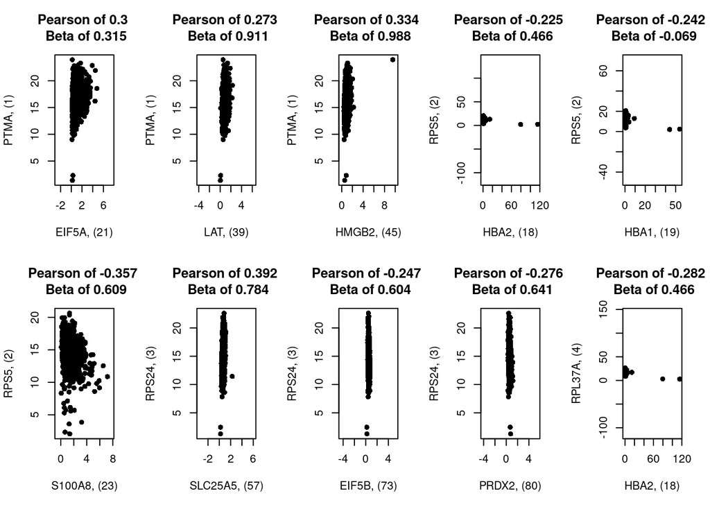

```r
par(mfrow = c(2, 5))
for (i in 1:nrow(cor_contrast_ind8)){
  index1 <- cor_contrast_ind8[i, 1]; index2 <- cor_contrast_ind8[i, 2]
  plot(sub_dat[,index1], sub_dat[,index2], asp = T,
       pch = 16, xlab = paste0(colnames(sub_dat)[index1], ", (", index1, ")"),
       ylab = paste0(colnames(sub_dat)[index2], ", (", index2, ")"),
       main = paste(paste0("Pearson of ", round(cor_pearson_mat[index1, index2], 3)),
                    "\n",
                    paste0("Beta of ", round(cor_blomqvist_mat[index1, index2], 3))))
}
```

## 2-9-1. Low Pearson (< 10%) and high Mutual Information (> 95%) (linearity vs information)

```r
cor_contrast9 <- ((abs(cor_pearson_mat) < quantile_mat["Pearson", 1]) &
                  (abs(cor_MI_mat) > quantile_mat["NMI", 2]))
cor_contrast_ind9 <- which(cor_contrast9, arr.ind = T)
cor_contrast_ind9 <- contrast_helper(cor_contrast_ind9, 3)

nrow(cor_contrast_ind9)
```

```
## [1] 10
```

## 2-9-2. Visualization of Low Pearson (< 10%) and high Mutual Information (> 95%) (linearity vs information)

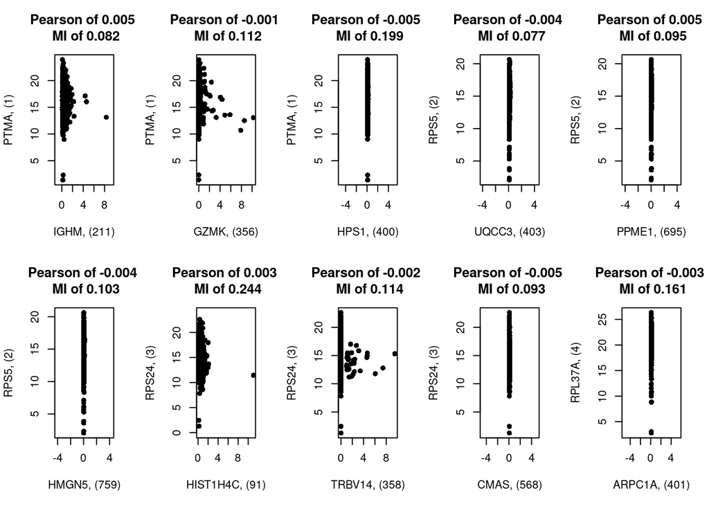

```r
par(mfrow = c(2, 5))
for (i in 1:nrow(cor_contrast_ind9)){
  index1 <- cor_contrast_ind9[i, 1]; index2 <- cor_contrast_ind9[i, 2]
  plot(sub_dat[,index1], sub_dat[,index2], asp = T,
       pch = 16, xlab = paste0(colnames(sub_dat)[index1], ", (", index1, ")"),
       ylab = paste0(colnames(sub_dat)[index2], ", (", index2, ")"),
       main = paste(paste0("Pearson of ", round(cor_pearson_mat[index1, index2], 3)),
                    "\n",
                    paste0("MI of ", round(cor_MI_mat[index1, index2], 3))))
}
```

## 2-10-1. High Pearson (> 95%) and Low Mutual Information (< 10%) (linearity vs information)

```r
cor_contrast10 <- ((abs(cor_pearson_mat) > quantile_mat["Pearson", 2]) &
                  (abs(cor_MI_mat) < quantile_mat["NMI", 1]))
cor_contrast_ind10 <- which(cor_contrast10, arr.ind = T)
cor_contrast_ind10 <- contrast_helper(cor_contrast_ind10, 3)

nrow(cor_contrast_ind10)
```

```
## [1] 1
```

## 2-10-2. Visualization of High Pearson (> 95%) and Low Mutual Information (< 10%) (linearity vs information)

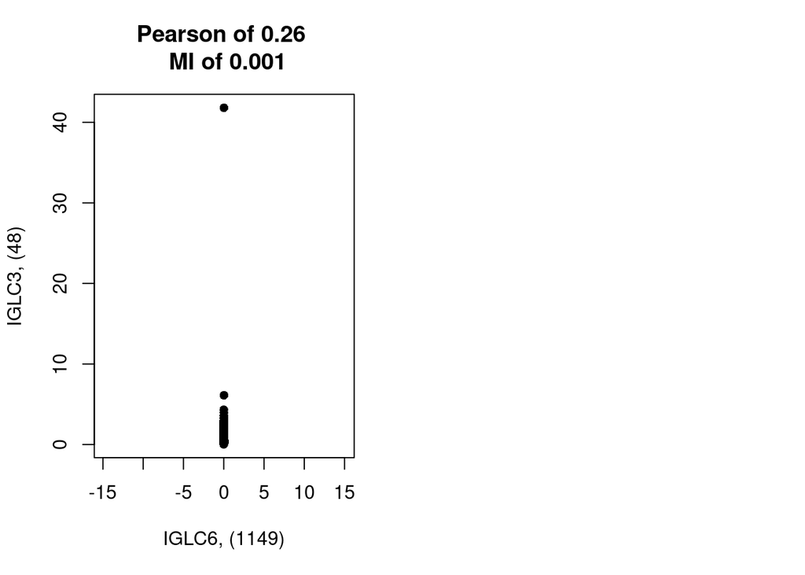

```r
par(mfrow = c(1, 2))
for (i in 1:nrow(cor_contrast_ind10)){
  index1 <- cor_contrast_ind10[i, 1]; index2 <- cor_contrast_ind10[i, 2]
  plot(sub_dat[,index1], sub_dat[,index2], asp = T,
       pch = 16, xlab = paste0(colnames(sub_dat)[index1], ", (", index1, ")"),
       ylab = paste0(colnames(sub_dat)[index2], ", (", index2, ")"),
       main = paste(paste0("Pearson of ", round(cor_pearson_mat[index1, index2], 3)),
                    "\n",
                    paste0("MI of ", round(cor_MI_mat[index1, index2], 3))))
}
```

## 2-11-1. Low Pearson (< 10%) and High XI (> 95%) (linearity vs non-linearity)

```r
cor_contrast11 <- ((abs(cor_pearson_mat) < quantile_mat["Pearson", 1]) &
                  (abs(cor_XI_mat) > quantile_mat["XI Corr", 2]))
cor_contrast_ind11 <- which(cor_contrast11, arr.ind = T)
cor_contrast_ind11 <- contrast_helper(cor_contrast_ind11, 3)

nrow(cor_contrast_ind11)
```

```
## [1] 10
```

## 2-11-2. Visualization of Low Pearson (< 10%) and High XI (> 95%) (linearity vs non-linearity)

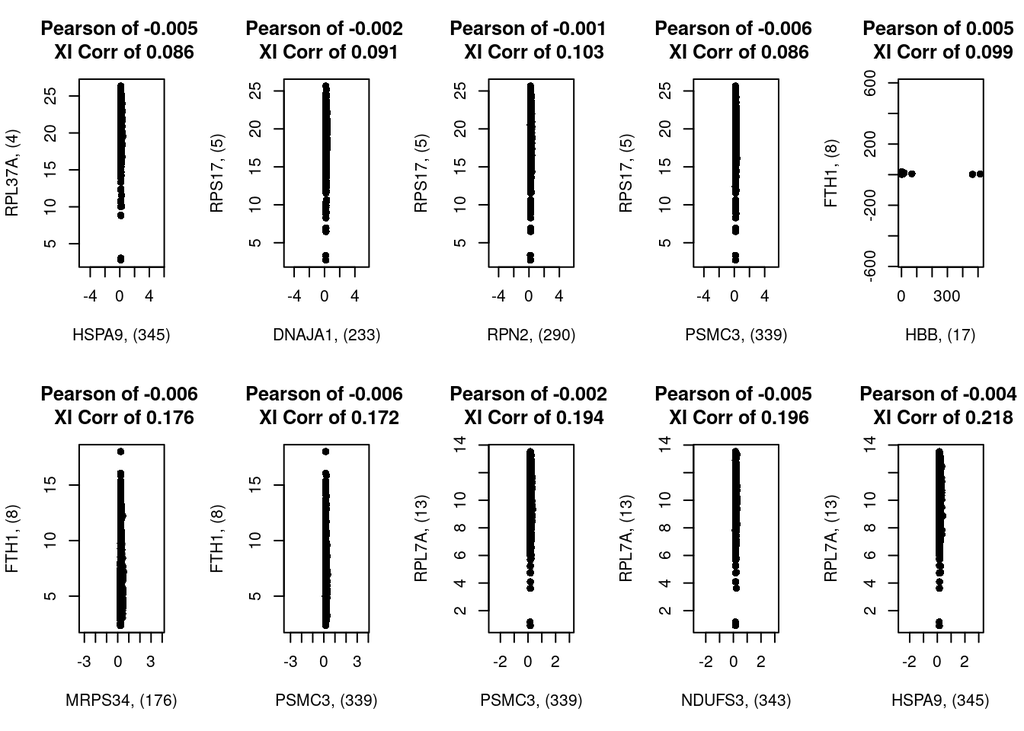

```r
par(mfrow = c(2,5))
for (i in 1:nrow(cor_contrast_ind11)){
  index1 <- cor_contrast_ind11[i, 1]; index2 <- cor_contrast_ind11[i, 2]
  plot(sub_dat[,index1], sub_dat[,index2], asp = T,
       pch = 16, xlab = paste0(colnames(sub_dat)[index1], ", (", index1, ")"),
       ylab = paste0(colnames(sub_dat)[index2], ", (", index2, ")"),
       main = paste(paste0("Pearson of ", round(cor_pearson_mat[index1, index2], 3)),
                    "\n",
                    paste0("XI Corr of ", round(cor_XI_mat[index1, index2], 3))))
}
```

## 2-12-1. High Pearson (> 95%) and Low XI (< 10%) (linearity vs non-linearity)

```r
cor_contrast12 <- ((abs(cor_pearson_mat) > quantile_mat["Pearson", 2]) &
                  (abs(cor_XI_mat) < quantile_mat["XI Corr", 1]))
cor_contrast_ind12 <- which(cor_contrast12, arr.ind = T)
cor_contrast_ind12 <- contrast_helper(cor_contrast_ind12, 3)

nrow(cor_contrast_ind12)
```

```
## [1] 10
```

## 2-12-2. Visualization of High Pearson (> 95%) and Low XI (< 10%) (linearity vs non-linearity)

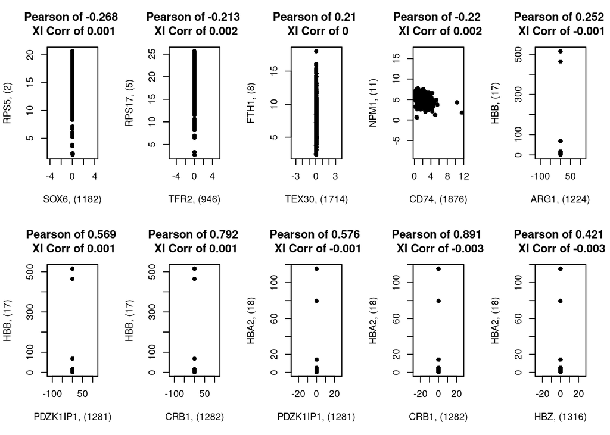

```r
par(mfrow = c(2, 5))
for (i in 1:nrow(cor_contrast_ind12)){
  index1 <- cor_contrast_ind12[i, 1]; index2 <- cor_contrast_ind12[i, 2]
  plot(sub_dat[,index1], sub_dat[,index2], asp = T,
       pch = 16, xlab = paste0(colnames(sub_dat)[index1], ", (", index1, ")"),
       ylab = paste0(colnames(sub_dat)[index2], ", (", index2, ")"),
       main = paste(paste0("Pearson of ", round(cor_pearson_mat[index1, index2], 3)),
                    "\n",
                    paste0("XI Corr of ", round(cor_XI_mat[index1, index2], 3))))
}
```

## 2-13-1. Low Spearman (< 10%) and High Distance Correlation (> 95%) (monotone vs non-linearity)

```r
cor_contrast13 <- ((abs(cor_spearman_mat) < quantile_mat["Spearman", 1]) &
                   (abs(cor_dist_mat) > quantile_mat["Dist. Corr", 2]))
cor_contrast_ind13 <- which(cor_contrast13, arr.ind = T)
cor_contrast_ind13 <- contrast_helper(cor_contrast_ind13, 3)

nrow(cor_contrast_ind13)
```

```
## [1] 0
```

## 2-13-2. Visualization of Low Spearman (< 10%) and High Distance Correlation (> 95%) (monotone vs non-linearity)

```r
# par(mfrow = c(2, 2))
# for (i in 1:nrow(cor_contrast_ind13)){
#   index1 <- cor_contrast_ind13[i, 1]; index2 <- cor_contrast_ind13[i, 2]
#   plot(sub_dat[,index1], sub_dat[,index2], asp = T,
#        pch = 16, xlab = paste0(colnames(sub_dat)[index1], ", (", index1, ")"),
#        ylab = paste0(colnames(sub_dat)[index2], ", (", index2, ")"),
#        main = paste(paste0("Spearman of ", round(cor_spearman_mat[index1, index2], 3)),
#                     "\n",
#                     paste0("Dist. Cor of ", round(cor_dist_mat[index1, index2], 3))))
# }
```

## 2-14-1. High Spearman (> 95%) and Low Distance Correlation (< 10%) (monotone vs non-linearity)

```r
cor_contrast14 <- ((abs(cor_spearman_mat) > quantile_mat["Spearman", 2]) &
                  (abs(cor_dist_mat) < quantile_mat["Dist. Corr", 1]))
cor_contrast_ind14 <- which(cor_contrast14, arr.ind = T)
cor_contrast_ind14 <- contrast_helper(cor_contrast_ind14, 3)

nrow(cor_contrast_ind14)
```

```
## [1] 10
```

## 2-14-2. Visualization of High Spearman (> 95%) and Low Distance Correlation (< 10%) (monotone vs non-linearity)

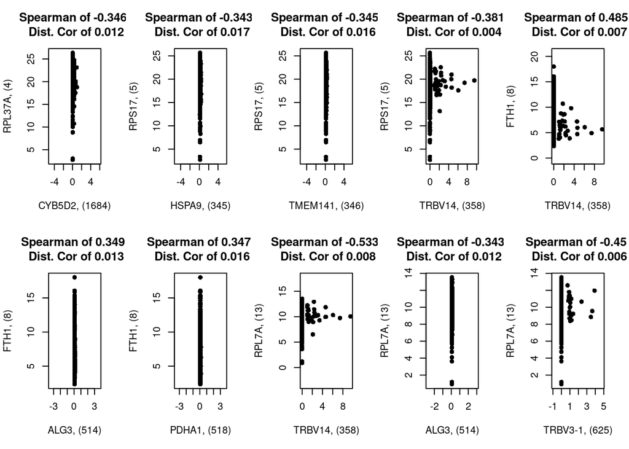

```r
par(mfrow = c(2, 5))
for (i in 1:nrow(cor_contrast_ind14)){
  index1 <- cor_contrast_ind14[i, 1]; index2 <- cor_contrast_ind14[i, 2]
  plot(sub_dat[,index1], sub_dat[,index2], asp = T,
       pch = 16, xlab = paste0(colnames(sub_dat)[index1], ", (", index1, ")"),
       ylab = paste0(colnames(sub_dat)[index2], ", (", index2, ")"),
       main = paste(paste0("Spearman of ", round(cor_spearman_mat[index1, index2], 3)),
                    "\n",
                    paste0("Dist. Cor of ", round(cor_dist_mat[index1, index2], 3))))
}
```

## 2-15-1. Low Spearman (< 10%) and High Blomqvist’s Beta (> 95%) (monotone vs monotone)

```r
cor_contrast15 <- ((abs(cor_spearman_mat) < quantile_mat["Spearman", 1]) &
                  (abs(cor_blomqvist_mat) > quantile_mat["Blomqvist's Beta", 2]))
cor_contrast_ind15 <- which(cor_contrast15, arr.ind = T)
cor_contrast_ind15 <- contrast_helper(cor_contrast_ind15, 3)

nrow(cor_contrast_ind15)
```

```
## [1] 0
```

## 2-15-2. Visualization of Low Spearman (< 10%) and High Blomqvist’s Beta (> 95%) (monotone vs monotone)

```r
# par(mfrow = c(2, 5))
# for (i in 1:nrow(cor_contrast_ind15)){
#   index1 <- cor_contrast_ind15[i, 1]; index2 <- cor_contrast_ind15[i, 2]
#   plot(sub_dat[,index1], sub_dat[,index2], asp = T,
#        pch = 16, xlab = paste0(colnames(sub_dat)[index1], ", (", index1, ")"),
#        ylab = paste0(colnames(sub_dat)[index2], ", (", index2, ")"),
#        main = paste(paste0("Spearman of ", round(cor_spearman_mat[index1, index2], 3)),
#                     "\n",
#                     paste0("Beta of ", round(cor_blomqvist_mat[index1, index2], 3))))
# }
```

## 2-16-1. High Spearman (> 95%) and Low Blomqvist’s Beta (< 10%) (monotone vs monotone)

```r
cor_contrast16 <- ((abs(cor_spearman_mat) > quantile_mat["Spearman", 2]) &
                  (abs(cor_blomqvist_mat) < quantile_mat["Blomqvist's Beta", 1]))
cor_contrast_ind16 <- which(cor_contrast16, arr.ind = T)
cor_contrast_ind16 <- contrast_helper(cor_contrast_ind16, 3)

nrow(cor_contrast_ind16)
```

```
## [1] 10
```

## 2-16-2. Visualization of High Spearman (> 95%) and Low Blomqvist’s Beta (< 10%) (monotone vs monotone)

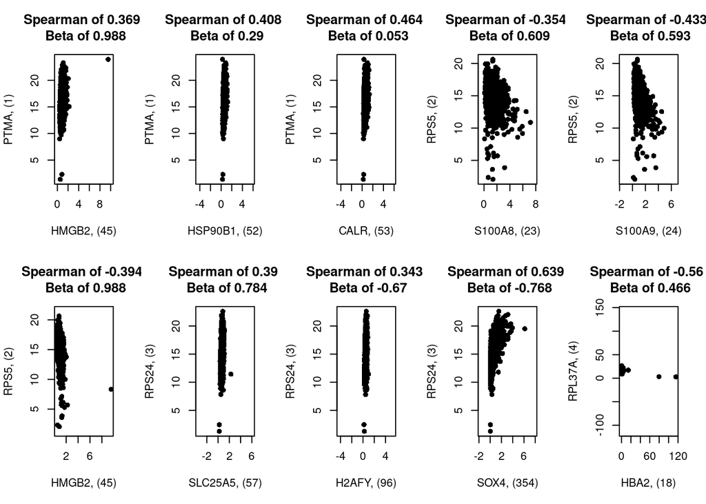

```r
par(mfrow = c(2, 5))
for (i in 1:nrow(cor_contrast_ind16)){
  index1 <- cor_contrast_ind16[i, 1]; index2 <- cor_contrast_ind16[i, 2]
  plot(sub_dat[,index1], sub_dat[,index2], asp = T,
       pch = 16, xlab = paste0(colnames(sub_dat)[index1], ", (", index1, ")"),
       ylab = paste0(colnames(sub_dat)[index2], ", (", index2, ")"),
       main = paste(paste0("Spearman of ", round(cor_spearman_mat[index1, index2], 3)),
                    "\n",
                    paste0("Beta of ", round(cor_blomqvist_mat[index1, index2], 3))))
}
```

## 2-17-1. Low Spearman (< 10%) and High Hoeffding’s D (> 95%) (monotone vs monotone)

```r
# cor_contrast17 <- ((abs(cor_spearman_mat) < quantile_mat["Spearman", 1]) &
#                   (abs(cor_hoeffd_mat) > quantile_mat["Hoeffding's D", 2]))
# cor_contrast_ind17 <- which(cor_contrast17, arr.ind = T)
# cor_contrast_ind17 <- contrast_helper(cor_contrast_ind17, 3)
#
# nrow(cor_contrast_ind17)
```

## 2-17-2. Visualization of Low Spearman (< 10%) and High Hoeffding’s D (> 95%) (monotone vs monotone)

```r
# par(mfrow = c(2, 5))
# for (i in 1:nrow(cor_contrast_ind17)){
#   index1 <- cor_contrast_ind17[i, 1]; index2 <- cor_contrast_ind17[i, 2]
#   plot(sub_dat[,index1], sub_dat[,index2], asp = T,
#        pch = 16, xlab = paste0(colnames(sub_dat)[index1], ", (", index1, ")"),
#        ylab = paste0(colnames(sub_dat)[index2], ", (", index2, ")"),
#        main = paste(paste0("Spearman of ", round(cor_spearman_mat[index1, index2], 3)),
#                     "\n",
#                     paste0("Hoeff D of ", round(cor_hoeffd_mat[index1, index2], 3))))
# }
```

## 2-18-1. High Spearman (> 95%) and Low Hoeffding’s D (< 10%) (monotone vs monotone)

```r
# cor_contrast18 <- ((abs(cor_spearman_mat) > quantile_mat["Spearman", 2]) &
#                   (abs(cor_hoeffd_mat) < quantile_mat["Hoeffding's D", 1]))
# cor_contrast_ind18 <- which(cor_contrast18, arr.ind = T)
# cor_contrast_ind18 <- contrast_helper(cor_contrast_ind18, 3)
#
# nrow(cor_contrast_ind18)
```

## 2-18-2. Visualization of High Spearman (> 95%) and Low Hoeffding’s D (< 10%) (monotone vs monotone)

```r
# par(mfrow = c(2, 5))
# for (i in 1:nrow(cor_contrast_ind18)){
#   index1 <- cor_contrast_ind18[i, 1]; index2 <- cor_contrast_ind18[i, 2]
#   plot(sub_dat[,index1], sub_dat[,index2], asp = T,
#        pch = 16, xlab = paste0(colnames(sub_dat)[index1], ", (", index1, ")"),
#        ylab = paste0(colnames(sub_dat)[index2], ", (", index2, ")"),
#        main = paste(paste0("Spearman of ", round(cor_spearman_mat[index1, index2], 3)),
#                     "\n",
#                     paste0("Hoeff D of ", round(cor_hoeffd_mat[index1, index2], 3))))
# }
```

## 2-19-1. Low Spearman (< 10%) and high Mutual Information (> 95%) (monotone vs information)

```r
cor_contrast19 <- ((abs(cor_spearman_mat) < quantile_mat["Spearman", 1]) &
                  (abs(cor_MI_mat) > quantile_mat["NMI", 2]))
cor_contrast_ind19 <- which(cor_contrast19, arr.ind = T)
cor_contrast_ind19 <- contrast_helper(cor_contrast_ind19, 3)

nrow(cor_contrast_ind19)
```

```
## [1] 10
```

## 2-19-2. Visualization of Low Spearman (< 10%) and high Mutual Information (> 95%) (monotone vs information)

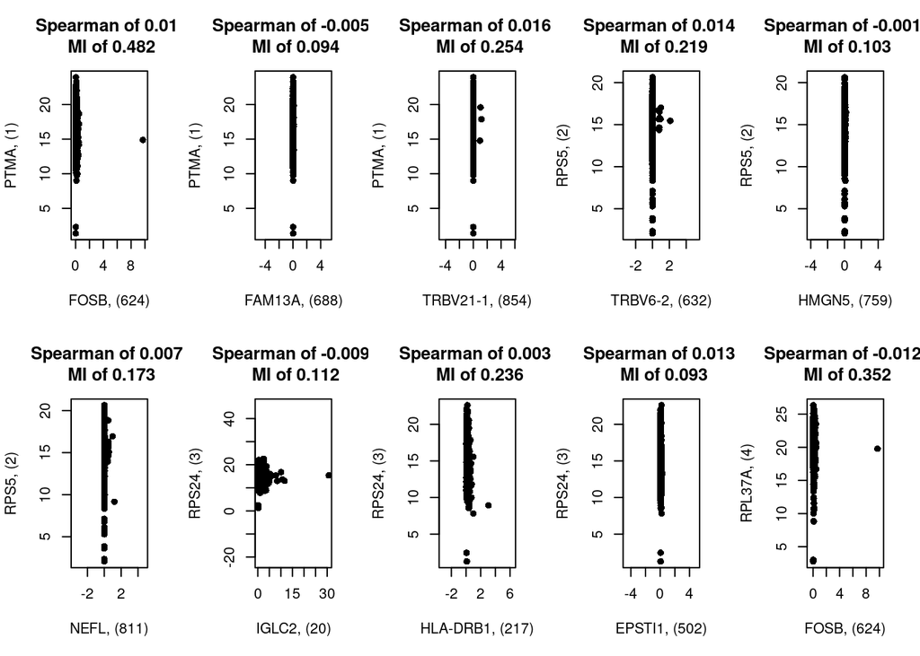

```r
par(mfrow = c(2, 5))
for (i in 1:nrow(cor_contrast_ind19)){
  index1 <- cor_contrast_ind19[i, 1]; index2 <- cor_contrast_ind19[i, 2]
  plot(sub_dat[,index1], sub_dat[,index2], asp = T,
       pch = 16, xlab = paste0(colnames(sub_dat)[index1], ", (", index1, ")"),
       ylab = paste0(colnames(sub_dat)[index2], ", (", index2, ")"),
       main = paste(paste0("Spearman of ", round(cor_spearman_mat[index1, index2], 3)),
                    "\n",
                    paste0("MI of ", round(cor_MI_mat[index1, index2], 3))))
}
```

## 2-20-1. High Spearman (> 95%) and Low Mutual Information (< 10%) (monotone vs information)

```r
cor_contrast20 <- ((abs(cor_spearman_mat) > quantile_mat["Spearman", 2]) &
                  (abs(cor_MI_mat) < quantile_mat["NMI", 1]))
cor_contrast_ind20 <- which(cor_contrast20, arr.ind = T)
cor_contrast_ind20 <- contrast_helper(cor_contrast_ind20, 3)

nrow(cor_contrast_ind20)
```

```
## [1] 10
```

## 2-20-2. Visualization of High Spearman (> 95%) and Low Mutual Information (< 10%) (monotone vs information)

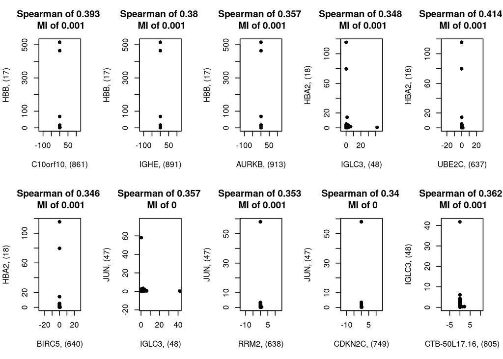

```r
par(mfrow = c(2, 5))
for (i in 1:nrow(cor_contrast_ind20)){
  index1 <- cor_contrast_ind20[i, 1]; index2 <- cor_contrast_ind20[i, 2]
  plot(sub_dat[,index1], sub_dat[,index2], asp = T,
       pch = 16, xlab = paste0(colnames(sub_dat)[index1], ", (", index1, ")"),
       ylab = paste0(colnames(sub_dat)[index2], ", (", index2, ")"),
       main = paste(paste0("Spearman of ", round(cor_spearman_mat[index1, index2], 3)),
                    "\n",
                    paste0("MI of ", round(cor_MI_mat[index1, index2], 3))))
}
```

## 2-21-1. Low Spearman (< 10%) and High XI (> 95%) (monotone vs non-linearity)

```r
cor_contrast21 <- ((abs(cor_spearman_mat) < quantile_mat["Spearman", 1]) &
                  (abs(cor_XI_mat) > quantile_mat["XI Corr", 2]))
cor_contrast_ind21 <- which(cor_contrast21, arr.ind = T)
cor_contrast_ind21 <- contrast_helper(cor_contrast_ind21, 3)

nrow(cor_contrast_ind21)
```

```
## [1] 10
```

## 2-21-2. Visualization of Low Spearman (< 10%) and High XI (> 95%) (monotone vs non-linearity)

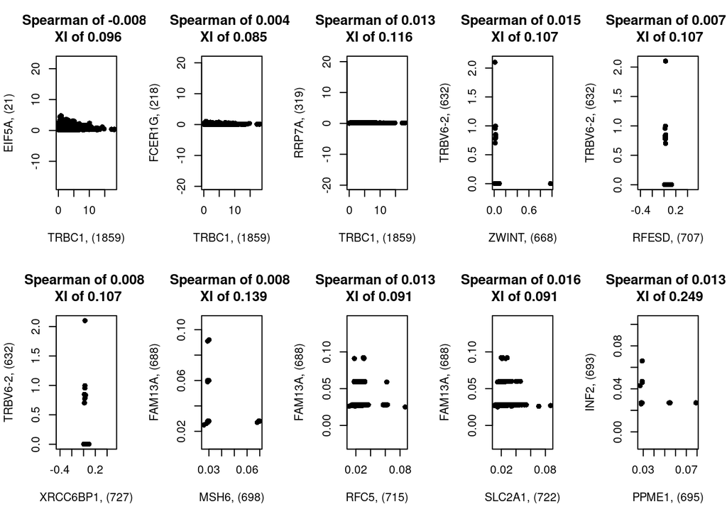

```r
par(mfrow = c(2, 5))
for (i in 1:nrow(cor_contrast_ind21)){
  index1 <- cor_contrast_ind21[i, 1]; index2 <- cor_contrast_ind21[i, 2]
  plot(sub_dat[,index1], sub_dat[,index2], asp = T,
       pch = 16, xlab = paste0(colnames(sub_dat)[index1], ", (", index1, ")"),
       ylab = paste0(colnames(sub_dat)[index2], ", (", index2, ")"),
       main = paste(paste0("Spearman of ", round(cor_spearman_mat[index1, index2], 3)),
                    "\n",
                    paste0("XI of ", round(cor_XI_mat[index1, index2], 3))))
}
```

## 2-22-1. High Spearman (> 95%) and Low XI (< 10%) (monotone vs non-linearity)

```r
cor_contrast22 <- ((abs(cor_spearman_mat) > quantile_mat["Spearman", 2]) &
                  (abs(cor_XI_mat) < quantile_mat["XI Corr", 1]))
cor_contrast_ind22 <- which(cor_contrast22, arr.ind = T)
cor_contrast_ind22 <- contrast_helper(cor_contrast_ind22, 3)

nrow(cor_contrast_ind22)
```

```
## [1] 10
```

## 2-22-2. Visualization of High Spearman (> 95%) and Low XI (< 10%) (monotone vs non-linearity)

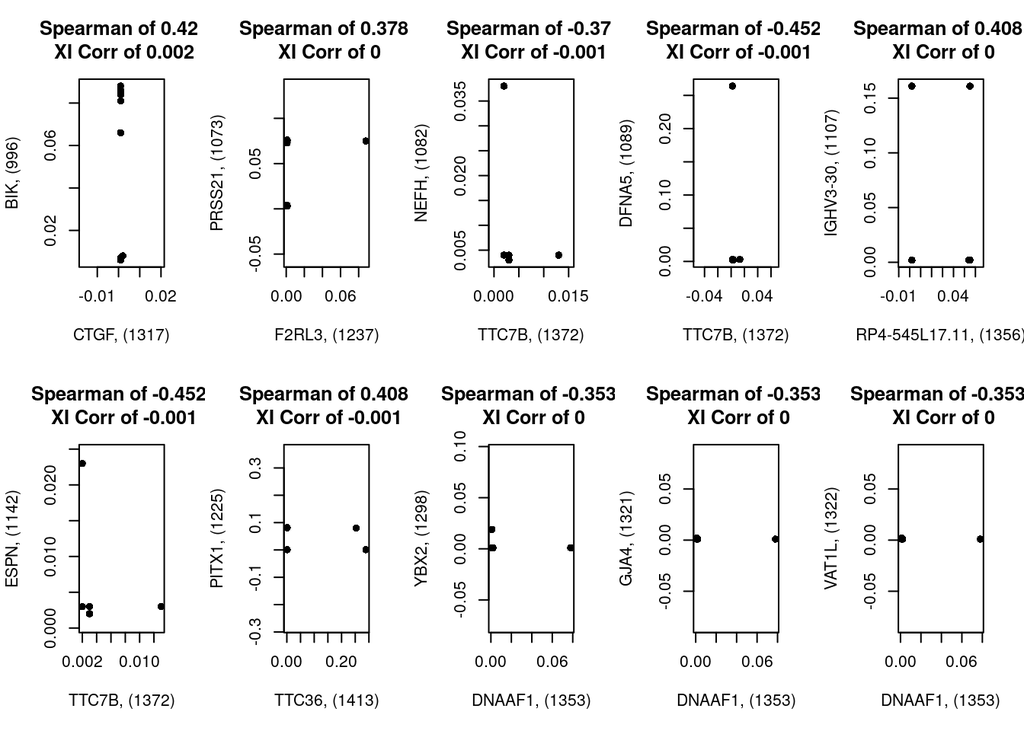

```r
par(mfrow = c(2, 5))
for (i in 1:nrow(cor_contrast_ind22)){
  index1 <- cor_contrast_ind22[i, 1]; index2 <- cor_contrast_ind22[i, 2]
  plot(sub_dat[,index1], sub_dat[,index2], asp = T,
       pch = 16, xlab = paste0(colnames(sub_dat)[index1], ", (", index1, ")"),
       ylab = paste0(colnames(sub_dat)[index2], ", (", index2, ")"),
       main = paste(paste0("Spearman of ", round(cor_spearman_mat[index1, index2], 3)),
                    "\n",
                    paste0("XI Corr of ", round(cor_XI_mat[index1, index2], 3))))
}
```

## 2-23-1. Low Distance Correlation (< 10%) and High Hoeffiding’s D (> 95%) (non-linearity vs monotone)

```r
# cor_contrast23 <- ((abs(cor_dist_mat) < quantile_mat["Dist. Corr", 1]) &
#                    (abs(cor_hoeffd_mat) > quantile_mat["Hoeffding's D", 2]))
# cor_contrast_ind23 <- which(cor_contrast23, arr.ind = T)
# cor_contrast_ind23 <- contrast_helper(cor_contrast_ind23, 3)
#
# nrow(cor_contrast_ind23)
```

## 2-23-2. Visualization of Low Distance Correlation (< 10%) and High Hoeffiding’s D (> 95%) (non-linearity vs monotone)

```r
# par(mfrow = c(1, 2))
# for (i in 1:nrow(cor_contrast_ind23)){
#   index1 <- cor_contrast_ind23[i, 1]; index2 <- cor_contrast_ind23[i, 2]
#   plot(sub_dat[,index1], sub_dat[,index2], asp = T,
#        pch = 16, xlab = paste0(colnames(sub_dat)[index1], ", (", index1, ")"),
#        ylab = paste0(colnames(sub_dat)[index2], ", (", index2, ")"),
#        main = paste(paste0("Dist. Cor of ", round(cor_dist_mat[index1, index2], 3)),
#                     "\n",
#                     paste0("Hoeffiding's D of ", round(cor_hoeffd_mat[index1, index2], 3))))
# }
```

## 2-24-1. High Distance Correlation (> 95%) and Low Hoeffiding’s D (< 10%) (non-linearity vs monotone)

```r
# cor_contrast24 <- ((abs(cor_dist_mat) > quantile_mat["Dist. Corr", 2]) &
#                    (abs(cor_hoeffd_mat) < quantile_mat["Hoeffding's D", 1]))
# cor_contrast_ind24 <- which(cor_contrast24, arr.ind = T)
# cor_contrast_ind24 <- contrast_helper(cor_contrast_ind24, 3)
#
# nrow(cor_contrast_ind24)
```

## 2-24-2. Visualization of High Distance Correlation (> 95%) and Low Hoeffiding’s D (< 10%) (non-linearity vs monotone)

```r
# par(mfrow = c(2, 2))
# for (i in 1:nrow(cor_contrast_ind24)){
#   index1 <- cor_contrast_ind24[i, 1]; index2 <- cor_contrast_ind24[i, 2]
#   plot(sub_dat[,index1], sub_dat[,index2], asp = T,
#        pch = 16, xlab = paste0(colnames(sub_dat)[index1], ", (", index1, ")"),
#        ylab = paste0(colnames(sub_dat)[index2], ", (", index2, ")"),
#        main = paste(paste0("Dist. Cor of ", round(cor_dist_mat[index1, index2], 3)),
#                     "\n",
#                     paste0("Hoeffiding's D of ", round(cor_hoeffd_mat[index1, index2], 3))))
# }
```

## 2-25-1. Low Distance Correlation (< 10%) and High XI (> 95%) (non-linearity vs non-linearity)

```r
cor_contrast25 <- ((abs(cor_dist_mat) < quantile_mat["Dist. Corr", 1]) &
                   (abs(cor_XI_mat) > quantile_mat["XI Corr", 2]))
cor_contrast_ind25 <- which(cor_contrast25, arr.ind = T)
cor_contrast_ind25 <- contrast_helper(cor_contrast_ind25, 3)

nrow(cor_contrast_ind25)
```

```
## [1] 10
```

## 2-25-2. Visualization of Low Distance Correlation (< 10%) and High XI (> 95%) (non-linearity vs non-linearity)

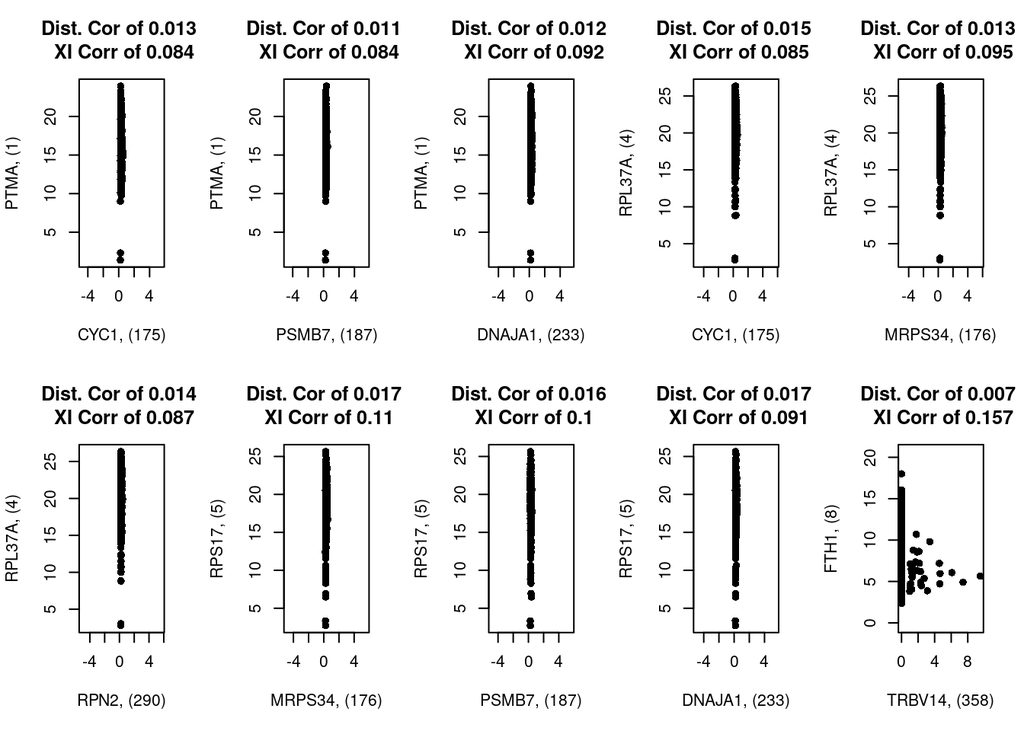

```r
par(mfrow = c(2, 5))
for (i in 1:nrow(cor_contrast_ind25)){
  index1 <- cor_contrast_ind25[i, 1]; index2 <- cor_contrast_ind25[i, 2]
  plot(sub_dat[,index1], sub_dat[,index2], asp = T,
       pch = 16, xlab = paste0(colnames(sub_dat)[index1], ", (", index1, ")"),
       ylab = paste0(colnames(sub_dat)[index2], ", (", index2, ")"),
       main = paste(paste0("Dist. Cor of ", round(cor_dist_mat[index1, index2], 3)),
                    "\n",
                    paste0("XI Corr of ", round(cor_XI_mat[index1, index2], 3))))
}
```

## 2-26-1. High Distance Correlation (> 95%) and Low XI (< 10%) (non-linearity vs non-linearity)

```r
cor_contrast26 <- ((abs(cor_dist_mat) > quantile_mat["Dist. Corr", 2]) &
                   (abs(cor_XI_mat) < quantile_mat["XI Corr", 1]))
cor_contrast_ind26 <- which(cor_contrast26, arr.ind = T)
cor_contrast_ind26 <- contrast_helper(cor_contrast_ind26, 3)

nrow(cor_contrast_ind26)
```

```
## [1] 1
```

## 2-26-2. Visualization of High Distance Correlation (> 95%) and Low XI (< 10%) (non-linearity vs non-linearity)

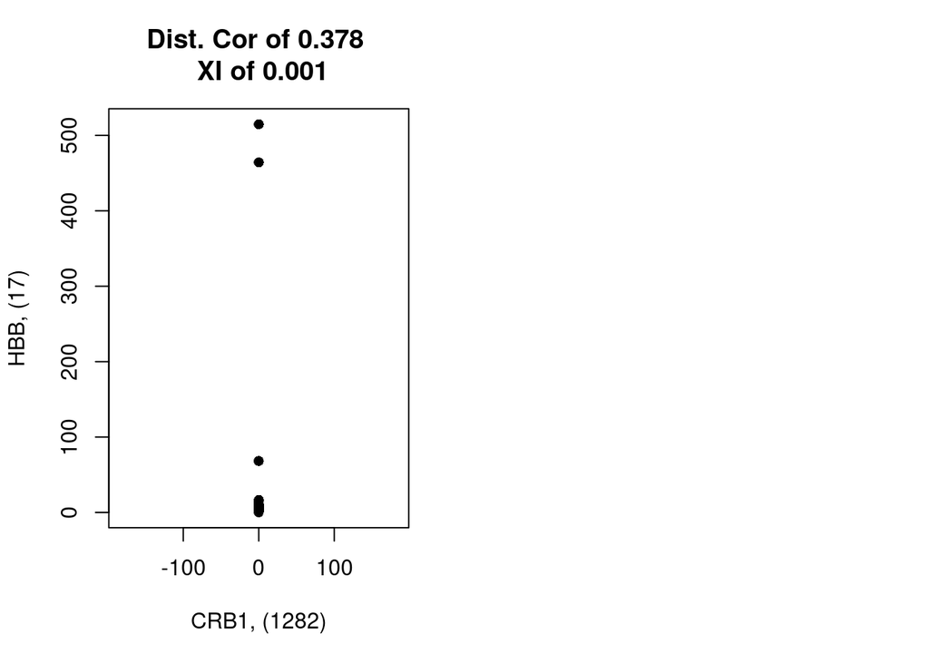

```r
par(mfrow = c(1, 2))
for (i in 1:nrow(cor_contrast_ind26)){
  index1 <- cor_contrast_ind26[i, 1]; index2 <- cor_contrast_ind26[i, 2]
  plot(sub_dat[,index1], sub_dat[,index2], asp = T,
       pch = 16, xlab = paste0(colnames(sub_dat)[index1], ", (", index1, ")"),
       ylab = paste0(colnames(sub_dat)[index2], ", (", index2, ")"),
       main = paste(paste0("Dist. Cor of ", round(cor_dist_mat[index1, index2], 3)),
                    "\n",
                    paste0("XI of ", round(cor_XI_mat[index1, index2], 3))))
}
```

## 2-27-1. Low Distance Correlation (< 10%) and High Blomqvist’s Beta (> 95%) (non-linearity vs non-linearity)

```r
cor_contrast27 <- ((abs(cor_dist_mat) < quantile_mat["Dist. Corr", 1]) &
                   (abs(cor_blomqvist_mat) > quantile_mat["Blomqvist's Beta", 2]))
cor_contrast_ind27 <- which(cor_contrast27, arr.ind = T)
cor_contrast_ind27 <- contrast_helper(cor_contrast_ind27, 3)

nrow(cor_contrast_ind27)
```

```
## [1] 0
```

## 2-27-2. Visualization of Low Distance Correlation (< 10%) and High Blomqvist’s Beta (> 95%) (non-linearity vs non-linearity)

```r
# par(mfrow = c(2, 5))
# for (i in 1:nrow(cor_contrast_ind27)){
#   index1 <- cor_contrast_ind27[i, 1]; index2 <- cor_contrast_ind27[i, 2]
#   plot(sub_dat[,index1], sub_dat[,index2], asp = T,
#        pch = 16, xlab = paste0(colnames(sub_dat)[index1], ", (", index1, ")"),
#        ylab = paste0(colnames(sub_dat)[index2], ", (", index2, ")"),
#        main = paste(paste0("Dist. Cor of ", round(cor_dist_mat[index1, index2], 3)),
#                     "\n",
#                     paste0("Beta of ", round(cor_blomqvist_mat[index1, index2], 3))))
# }
```

## 2-28-1. High Distance Correlation (> 95%) and Low Blomqvist’s Beta (< 10%) (non-linearity vs non-linearity)

```r
cor_contrast28 <- ((abs(cor_dist_mat) > quantile_mat["Dist. Corr", 2]) &
                   (abs(cor_blomqvist_mat) < quantile_mat["Blomqvist's Beta", 1]))
cor_contrast_ind28 <- which(cor_contrast28, arr.ind = T)
cor_contrast_ind28 <- contrast_helper(cor_contrast_ind28, 3)

nrow(cor_contrast_ind28)
```

```
## [1] 10
```

## 2-28-2. Visualization of High Distance Correlation (> 95%) and Low Blomqvist’s Beta (< 10%) (non-linearity vs non-linearity)

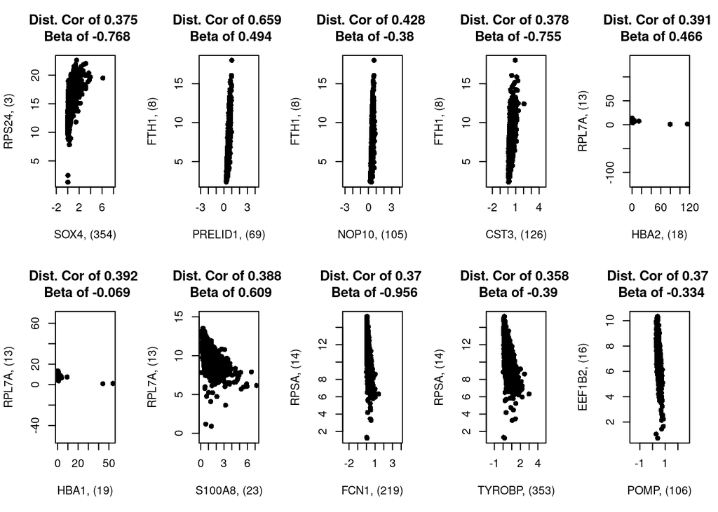

```r
par(mfrow = c(2, 5))
for (i in 1:nrow(cor_contrast_ind28)){
  index1 <- cor_contrast_ind28[i, 1]; index2 <- cor_contrast_ind28[i, 2]
  plot(sub_dat[,index1], sub_dat[,index2], asp = T,
       pch = 16, xlab = paste0(colnames(sub_dat)[index1], ", (", index1, ")"),
       ylab = paste0(colnames(sub_dat)[index2], ", (", index2, ")"),
       main = paste(paste0("Dist. Cor of ", round(cor_dist_mat[index1, index2], 3)),
                    "\n",
                    paste0("Beta of ", round(cor_blomqvist_mat[index1, index2], 3))))
}
```

# 3. Explore dense plots

## 3-1. Visualize dense plot

```r
dense_ind <- rbind(c(345, 13), c(1375, 18), c(45, 1),
                   c(23, 2), c(1282, 18), c(354, 3), c(219, 14))

dense_mat <- matrix(nrow = nrow(dense_ind), ncol = 8)
for (i in 1:nrow(dense_ind)){
  row <- dense_ind[i,1]; col <- dense_ind[i,2];
  h <- c()
  for (j in 1:length(cor_mat_list)){
    if (j == 4){
      h <- c(h, NA)
      next
    }
    cur_mat <- cor_mat_list[[j]]
    h <- c(h, cur_mat[row, col])
  }
  dense_mat[i, ] <- h
}

fun_lable <- c("Pearson", "Spearman", "Kendall",
               "Hoeff D", "Blomq Beta", "NMI",
                "Dist Cor", "XI")
colnames(dense_mat) <- fun_lable

dense_title <-
  c(paste(paste0("Pearson of ", round(cor_pearson_mat[dense_ind[1,1], dense_ind[1,2]], 3),
                         "  Dist Cor of ", round(cor_dist_mat[dense_ind[1,1], dense_ind[1,2]], 3)),
                  "\n",
                  paste0("Beta of ", round(cor_blomqvist_mat[dense_ind[1,1], dense_ind[1,2]], 3))),
    paste(paste0("Spearman of ", round(cor_spearman_mat[dense_ind[2,1], dense_ind[2,2]], 3),
                         "  NMI of ", round(cor_MI_mat[dense_ind[2,1], dense_ind[2,2]], 3)),
                  "\n",
                  paste0("Beta of ", round(cor_blomqvist_mat[dense_ind[2,1], dense_ind[2,2]], 3))),
    paste(paste0("XI of ", round(cor_XI_mat[dense_ind[3,1], dense_ind[3,2]], 3),
                 "  Dist Cor of ", round(cor_dist_mat[dense_ind[3,1], dense_ind[3,2]], 3)),
                  "\n",
                  paste0("NMI of ", round(cor_MI_mat[dense_ind[3,1], dense_ind[3,2]], 3),
                         " Beta of", round(cor_blomqvist_mat[dense_ind[3,1], dense_ind[3,2]], 3))),
    paste(paste0("XI of ", round(cor_XI_mat[dense_ind[4,1], dense_ind[4,2]], 3),
                 "  NMI of ", round(cor_MI_mat[dense_ind[4,1], dense_ind[4,2]], 3)),
                  "\n",
                  paste0("Pearson of ", round(cor_pearson_mat[dense_ind[4,1], dense_ind[4,2]], 3),
                         "  Beta of ", round(cor_blomqvist_mat[dense_ind[4,1], dense_ind[4,2]], 3))),
    paste(paste0("Spearman of ", round(cor_spearman_mat[dense_ind[5,1], dense_ind[5,2]], 3),
                 "  XI of ", round(cor_XI_mat[dense_ind[5,1], dense_ind[5,2]], 3)),
                  "\n",
          paste0("Pearson of ", round(cor_pearson_mat[dense_ind[5,1], dense_ind[5,2]], 3))),
    paste(paste0("XI of ", round(cor_XI_mat[dense_ind[6,1], dense_ind[6,2]], 3)),
                  "\n",
          paste0("NMI of ", round(cor_MI_mat[dense_ind[6,1], dense_ind[6,2]], 3))),

    paste(paste0("XI of ", round(cor_XI_mat[dense_ind[7,1], dense_ind[7,2]], 3),
                 "  Dist Cor of ", round(cor_dist_mat[dense_ind[7,1], dense_ind[7,2]], 3)),
                  "\n",
          paste0("Beta of ", round(cor_blomqvist_mat[dense_ind[7,1], dense_ind[7,2]], 3)))
    )
```

## 3-2. Visualize with contour plots (density)

```r
#' Plotting density
#'
#' @param mat matrix
#' @param grid_spacing numeric vector
#' @param n integer for \code{stats::kde}
#' @param max_num integer
#' @param density_colors color vector
#' @param point_color color
#' @param contour_color color
#' @param grid_color color
#' @param pch integer
#' @param contour_lwd numeric
#' @param grid_lty integer
#' @param grid_lwd numeric
#' @param ... additional graphical parameters
#'
#' @return nothing
#' @export
plot_density <- function(mat, grid_spacing,
                         xlim,
                         ylim,
                         n = 100,
                         max_num = 20000,
                         density_colors = grDevices::heat.colors(100, alpha = 0.8),
                         point_color = grDevices::rgb(0.5, 0.5, 0.5, 0.8),
                         contour_color = grDevices::rgb(1,1,1,0.5),
                         grid_color = "gray",
                         xaxt = "n",
                         yaxt = "n",
                         axes = F,
                         xlab = "",
                         ylab = "",
                         pch = 16,
                         contour_lwd = 2,
                         grid_lty = 2,
                         grid_lwd = 0.5,
                         ...){
  stopifnot(ncol(mat) == 2)

  mat2 <- rbind(mat,
                c(xlim[1], ylim[1]),
                c(xlim[1], ylim[2]),
                c(xlim[2], ylim[1]),
                c(xlim[2], ylim[2]))
  f1 <- MASS::kde2d(mat2[,1], mat2[,2], n = 100)
  graphics::image(f1,
                  col = density_colors,
                  xlim = xlim,
                  ylim = ylim,
                  ...)

  for(i in grid_spacing){
    graphics::lines(rep(i,2), c(-2,2)*max(abs(grid_spacing)),
                    lty = grid_lty,
                    lwd = grid_lwd,
                    col = grid_color)
    graphics::lines(c(-2,2)*max(abs(grid_spacing)), rep(i,2),
                    lty = grid_lty,
                    lwd = grid_lwd,
                    col = grid_color)
  }

  if(nrow(mat) > max_num) {
    idx <- sample(1:nrow(mat), size = max_num)
  } else {
    idx <- 1:nrow(mat)
  }
  graphics::points(mat[idx,1], mat[idx,2],
                   col = point_color,
                   pch = pch)

  graphics::contour(f1, add = T,
                    drawlabels = F,
                    col = contour_color,
                    lwd = contour_lwd)

  invisible()
}
```

```r
# par(mfrow = c(1, 2))
# for (i in 1:nrow(dense_ind)){
#   index1 <- dense_ind[i, 1]; index2 <- dense_ind[i, 2];
#   plot(sub_dat[,index1], sub_dat[,index2], asp = T,
#        pch = 16, xlab = paste0(colnames(sub_dat)[index1], ", (", index1, ")"),
#        ylab = paste0(colnames(sub_dat)[index2], ", (", index2, ")"),
#        main = dense_title[i])
#   xylim <- par("usr")
#
#   x <- sub_dat[,index1]; y <- sub_dat[,index2];
#   xmin <- min(x); xmax <- max(x); ymin <- min(y); ymax <- max(y);
#   total_min <- min(xmin, ymin); total_max <- max(xmax, ymax);
#
#   plot_density(cbind(x, y),
#                grid_spacing = seq(total_min, total_max, by=((total_max - total_min) / 10)),
#                xlim = c(xylim[1], xylim[2]), ylim = c(xylim[3], xylim[4]),
#                xlab = paste0(colnames(sub_dat)[index1], ", (", index1, ")"),
#                ylab = paste0(colnames(sub_dat)[index2], ", (", index2, ")"))
#
# }
```

## 3-3 Visualize with HexBin

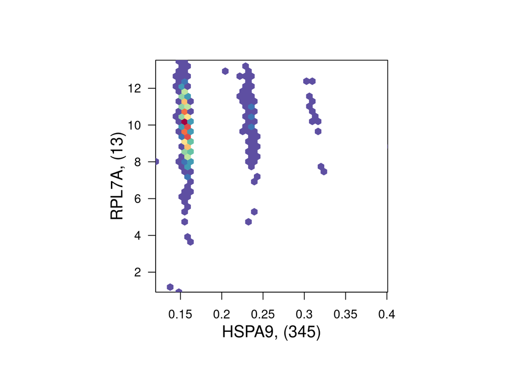

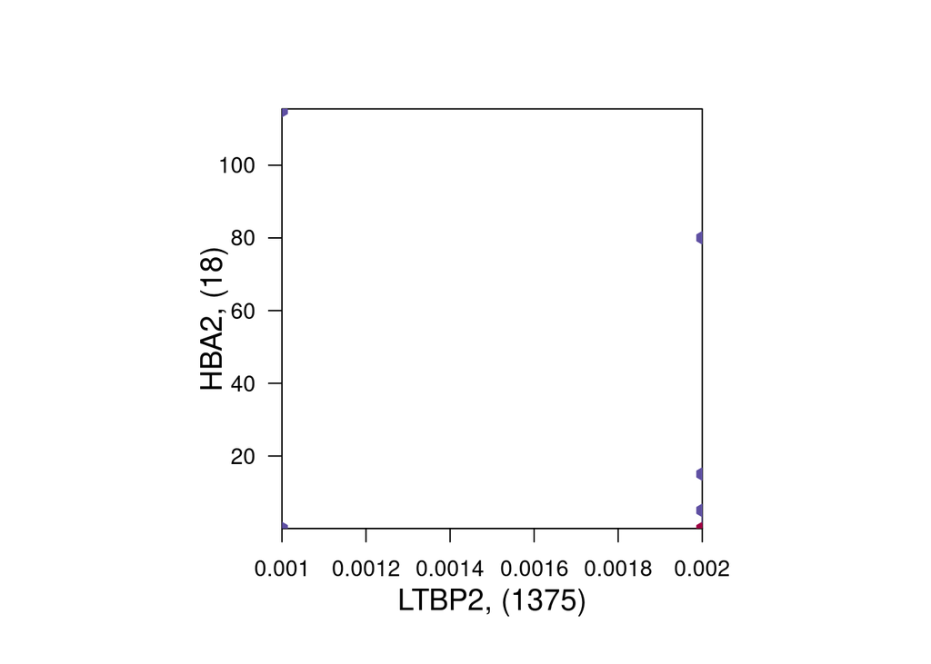

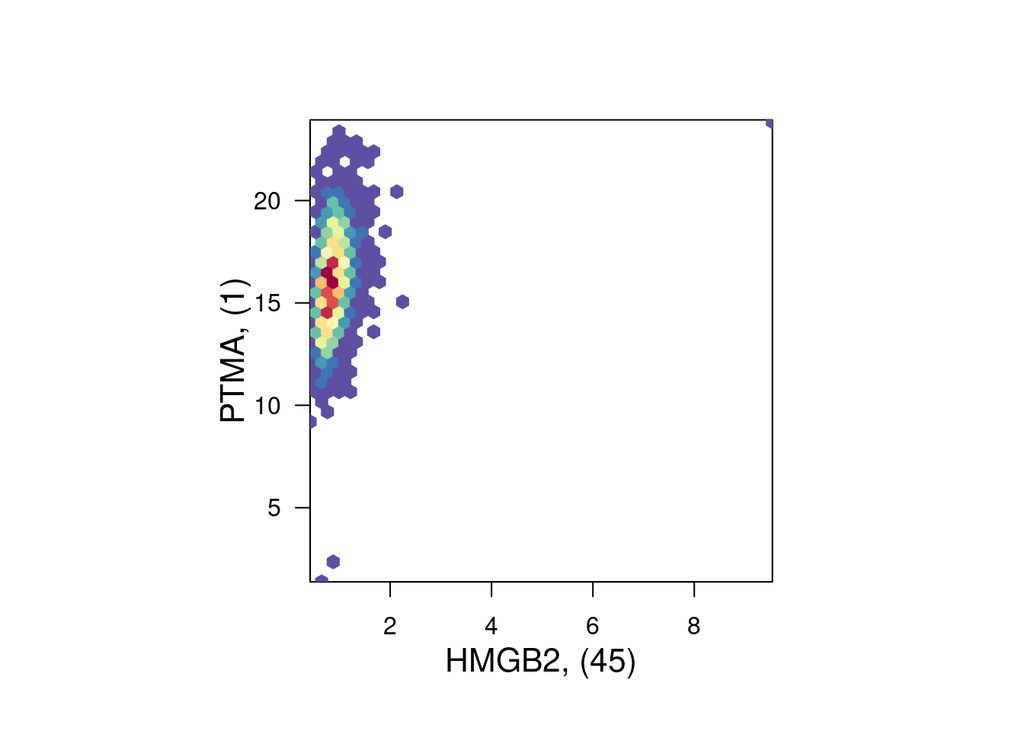

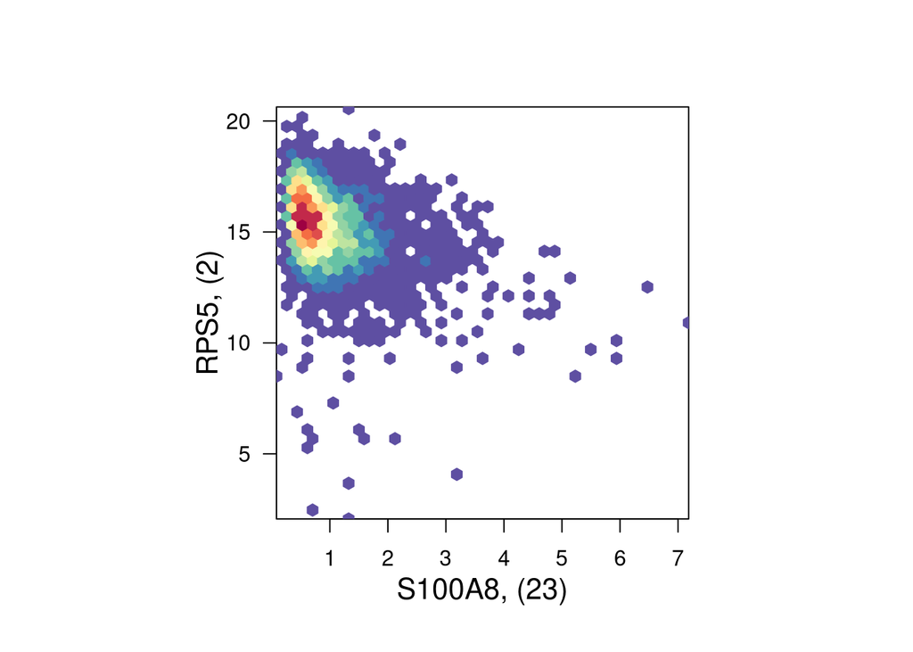

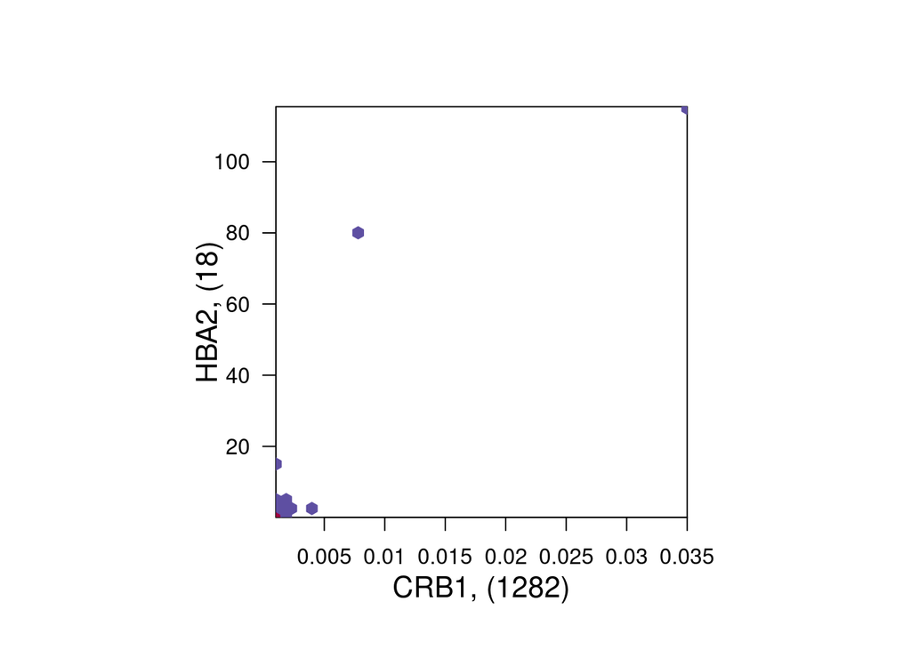

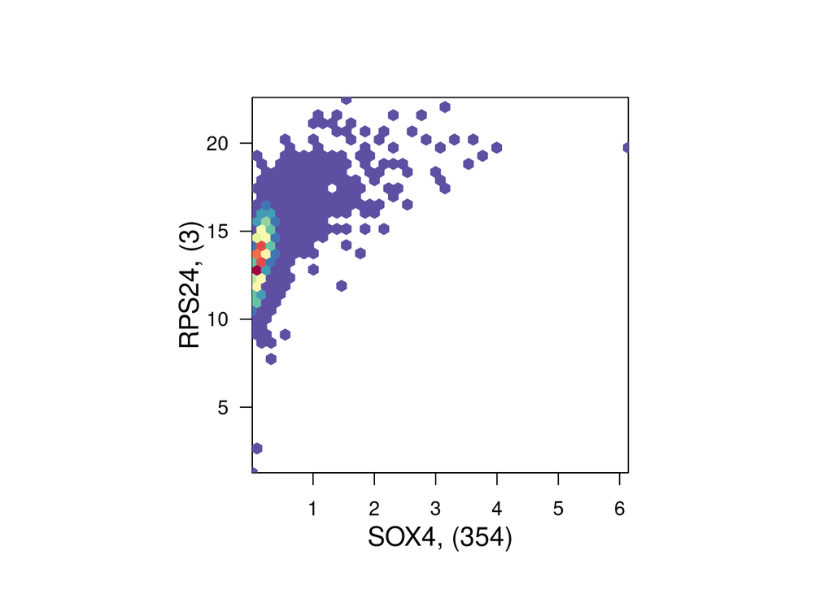

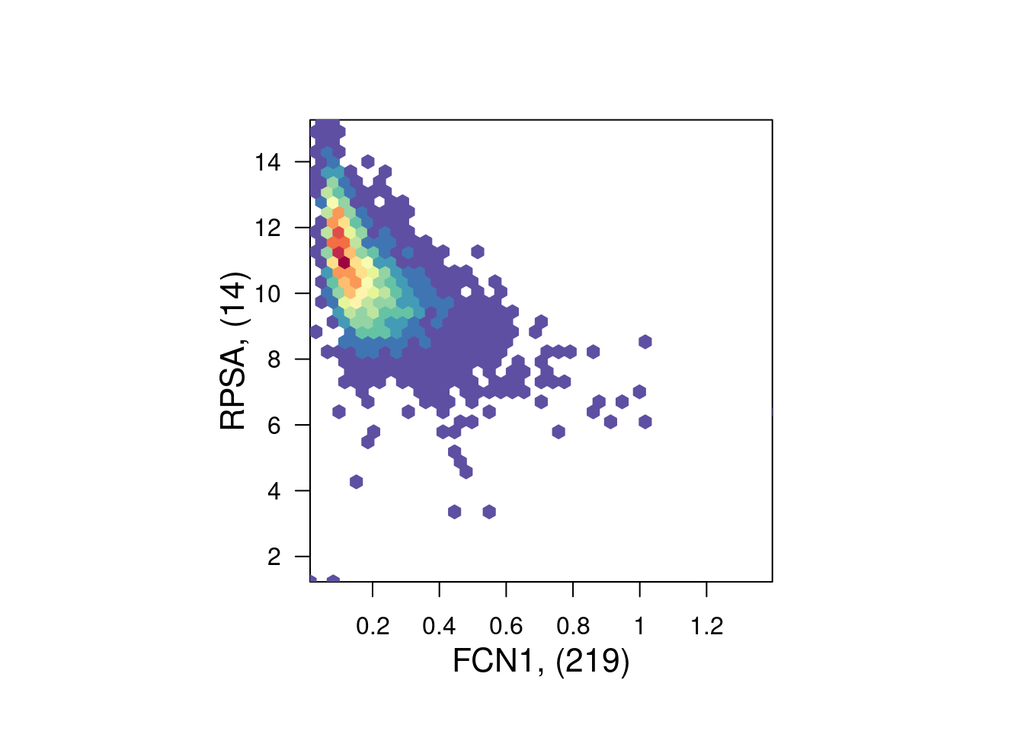

```r
library(hexbin)
library(RColorBrewer)

par(mfrow = c(2,3))
for (i in 1:nrow(dense_ind)){
  index1 <- dense_ind[i, 1]; index2 <- dense_ind[i, 2];
  bin <- hexbin(sub_dat[,index1], sub_dat[,index2], xbins = 40)
  my_colors=colorRampPalette(rev(brewer.pal(11, 'Spectral')))
  plot(bin, colramp = my_colors, legend = F,
       xlab = paste0(colnames(sub_dat)[index1], ", (", index1, ")"),
       ylab = paste0(colnames(sub_dat)[index2], ", (", index2, ")"))
}
```